# WoLKE-Studie

- Show All Code
- Hide All Code
- View Source

Author

Benedikt Beuttler & Heiko Holz

Published

May 7, 2026

# 1 Merging 2025 and 2026 data

```r
if (FALSE) {
  install.packages("renv") #1
  renv::restore() #2
}
```

# 2 Preamble

## 2.1 Prepare the Environment

## 2.2 Load Libraries

```r
# install pacman
if (!requireNamespace("pacman", quietly = TRUE)) {
  install.packages("pacman")
}
library(pacman)

## Pfad/Utilities
p_load(this.path)

## Wrangling
# use pacman to load packages
p_load(dplyr, tidyr, stringr, forcats, purrr, magrittr)

## Ähnlichkeit/Text
p_load(stringdist, psych)

## Modellierung
p_load(lavaan, lme4, lmerTest, emmeans, estimatr)

## Tabellen/Reporting
# install.packages("remotes")

# remotes::install_version(
#   "modelsummary",
#   version = "2.5.0",
#   repos = "https://cran.r-project.org"
# )

p_load(modelsummary)
p_load(kableExtra, arsenal)

p_load(patchwork)

## Visualisierung/Themes
p_load(ggplot2, ggsci, jtools)

p_load(mnormt)

source(file = "functions.r") # all outsourced funtions
```

```r
is_word <- !(knitr::is_html_output() | knitr::is_latex_output())

if (is_word) {
  p_load(flextable)
}
```

## 2.3 Load Pre- and Posttest and Reshape Data

```r
#define vars
covars <- c(
  "time",
  "gender",
  "semester",
  "location",
  "intervention",
  "age",
  "students",
  "group"
)
controls <- c("gender", "semester", "location")
random_terms_lmer <- c("(1 | code)")
groups <- c("intervention")
time <- "time"
outcomes <- c(
  # "AILIT",
  "AILIT26",
  "AILITwolke",
  "AILITglat",
  "TK",
  "TPK",
  "TCK",
  "TPACKce",
  "TPACKgenai",
  "Ethics",
  "CEA",
  "CEA_understanding",
  "CEA_ped",
  "PU"
)
outcomes_ailit <- c("AILIT26", "AILITwolke", "AILITglat") #removed AILIT
outcomes_tpack <- c("TK", "TPK", "TCK", "TPACKce", "TPACKgenai", "Ethics")
outcomes_cea <- c("CEA", "CEA_understanding", "CEA_ped")
q_column_names <- c("AI", "GL", "TP", "RE02", "ED", "NP")
vars_num <- c("age", "semester") # numeric outcomes
vars_cat <- c("gender", "students") # categorical outcomes`
```

```r
# load pre-prepared data
# 25
load("data/25/25-data_all.Rdata") # nicht nach pre und posttest gefiltert
load("data/25/25-data.Rdata") # probanden mit pre UND posttest

# 26
load("data/26/26-data_all.Rdata") # nicht nach pre und posttest gefiltert
load("data/26/26-data.Rdata") # probanden mit pre UND posttest
# load all Rdata from folder /data/dropouts
files <- list.files(
  "data/26/dropouts",
  pattern = "\\.Rdata$",
  full.names = TRUE
)
invisible(lapply(files, load, envir = .GlobalEnv))

data_merged <- bind_rows(
  data_25 %>%
    select(
      code,
      starts_with(q_column_names, ignore.case = FALSE),
      all_of(covars)
    ) %>%
    mutate(
      wave = "sose25",
      across(c(starts_with(q_column_names), semester, age), as.integer)
    ),

  data_26 %>%
    select(
      code,
      starts_with(q_column_names, ignore.case = FALSE),
      all_of(covars)
    ) %>%
    mutate(
      wave = "wise26",
      across(c(starts_with(q_column_names), semester, age), as.integer)
    )
)
data_merged$gender <- droplevels(data_merged$gender)

data_all_merged <- bind_rows(
  data_all_25 %>%
    select(
      code,
      starts_with(q_column_names),
      all_of(covars)
    ) %>%
    mutate(
      wave = "sose25",
      across(c(starts_with(q_column_names), semester, age), as.integer)
    ),

  data_all_26 %>%
    select(
      code,
      starts_with(q_column_names),
      all_of(covars)
    ) %>%
    mutate(
      wave = "wise26",
      across(c(starts_with(q_column_names), semester, age), as.integer)
    )
)

data_merged_pre <- data_merged %>% filter(time == "pre")
data_all_merged_pre <- data_all_merged %>% filter(time == "pre")
```

```r
### grouping scales
## TPACK
# all TPACK items used
list_items_i_tpack <- list(
  "TK" = grep("^TP01_", names(data_merged), value = T),
  "TPK" = grep("^TP02_", names(data_merged), value = T),
  "TCK" = grep("^TP03_", names(data_merged), value = T),
  "TPACK_ce" = grep("^TP04_(0[1-8]|12|15)$", names(data_merged), value = T), # Sub-Subskala 1: Celik Enhanced Items
  "TPACK_genai" = grep(
    "^TP04_(09|10|11|13|14)$",
    names(data_merged),
    value = T
  ), # Sub-Subskala 2: GenAI Items
  "Ethics" = grep("^TP05_0[1-6]$", names(data_merged), value = T) #im pretest nur items 1-6 vorhanden 7,8 kamen im post dazu
)

## Perceived Usefulnes
list_items_pu <- list(
  "Pu" = grep("^ED03_", names(data_merged), value = T)
)

# ein paar ethik items müssen noch rausgenommen werden, die nur im posttest erhoben wurden. hier nur check
# data_subset1 <- data %>% select(all_of(unlist(list_items_i_tpack)))
# View(data_subset1)

## Critical Evaluation of AI
list_items_cea <- list(
  "CEA" = grep("^RE02_(0[1-9])$", names(data_merged), value = T),
  "CEA_understanding" = grep("^RE02_(0[1-4])$", names(data_merged), value = T),
  "CEA_ped" = grep("^RE02_(0[5-9])$", names(data_merged), value = T)
)
# data_subset3 <- data %>% select(all_of(unlist(list_items_cea)))
# sum(data_subset3 < 0, na.rm = TRUE)

## AI Literacy
ailit_wolke_items <- c(
  "AI36_04",
  "AI36_10",
  "AI36_11",
  "AI36_13",
  "AI36_15",
  "AI36_16",
  "AI36_17",
  "AI36_19",
  "AI36_24",
  "AI36_25",
  "AI36_27"
)
ailit_glat_items <- c(
  "GL21_01",
  "GL21_02",
  "GL21_03",
  "GL21_04",
  "GL21_05",
  "GL21_06",
  "GL21_07",
  "GL21_08",
  "GL21_09",
  "GL21_10",
  "GL21_11",
  "GL21_12",
  "GL21_13",
  "GL21_14",
  "GL21_15",
  "GL21_16",
  "GL21_17",
  "GL21_18",
  "GL21_19"
)

list_items_ailit <- list(
  "ailit" = grep(
    paste0(
      "^(",
      paste(c(ailit_wolke_items, ailit_glat_items), collapse = "|"),
      ")$"
    ),
    names(data_merged),
    value = TRUE
  ),
  "ailit_wolke" = grep(
    paste0("^(", paste(ailit_wolke_items, collapse = "|"), ")$"),
    names(data_merged),
    value = TRUE
  ),
  "ailit_glat" = grep(
    paste0("^(", paste(ailit_glat_items, collapse = "|"), ")$"),
    names(data_merged),
    value = TRUE
  )
)

# create new columns with the means of the lists
data_merged <- data_merged %>%
  mutate(
    # AILIT = rowSums(cbind(AI35_02, GL20_01), na.rm = TRUE), # default sumscore overall AI Lit
    AILIT26 = if_else(
      wave == "wise26",
      rowSums(cbind(AI35_02, GL20_01), na.rm = TRUE),
      NA_real_
    ),
    AILITwolke = rowSums(
      select(., all_of(list_items_ailit$ailit_wolke)),
      na.rm = TRUE
    ),
    AILITglat = GL20_01,
    TK = rowMeans(select(., all_of(list_items_i_tpack$TK)), na.rm = TRUE),
    TPK = rowMeans(select(., all_of(list_items_i_tpack$TPK)), na.rm = TRUE),
    TCK = rowMeans(select(., all_of(list_items_i_tpack$TCK)), na.rm = TRUE),
    TPACKce = rowMeans(
      select(., all_of(list_items_i_tpack$TPACK_ce)),
      na.rm = TRUE
    ),
    TPACKgenai = rowMeans(
      select(., all_of(list_items_i_tpack$TPACK_genai)),
      na.rm = TRUE
    ),
    Ethics = rowMeans(
      select(., all_of(list_items_i_tpack$Ethics)),
      na.rm = TRUE
    ),
    TPACK_total = rowMeans(
      select(., all_of(unlist(list_items_i_tpack))),
      na.rm = TRUE
    ),
    CEA = rowMeans(select(., all_of(list_items_cea$CEA)), na.rm = TRUE),
    CEA_understanding = rowMeans(
      select(., all_of(list_items_cea$CEA_understanding)),
      na.rm = TRUE
    ),
    CEA_ped = rowMeans(select(., all_of(list_items_cea$CEA_ped)), na.rm = TRUE),
    PU = rowMeans(select(., all_of(list_items_pu$Pu)), na.rm = TRUE),
    PU1 = ED03_01,
    PU2 = ED03_02,
    PU3 = ED03_03,
    PU4 = ED03_04
  )

# check missing values in TPACK and PU scales (NA means, not answered (-1 diff. answer, -9 not answered)) -> this comes from ethic items
data_merged %>%
  select(all_of(c(list_items_i_tpack) %>% unlist)) %>%
  summarise(across(everything(), ~ sum(is.na(.x)))) %>%
  sum # 0
```

```
[1] 7
```

```r
data_merged_long <- data_merged %>%
  pivot_longer(
    cols = all_of(outcomes),
    names_to = "outcome",
    values_to = "score"
  ) %>%
  mutate(
    outcome = factor(outcome, levels = outcomes)
  )
```

# 3 Methods

## 3.1 Participants

```r
p_load(dplyr, tidyr) # needs to be called for rendering to work

data_participants <- data_merged %>%
  filter(time == "pre") %>%
  group_by(intervention, location, gender) %>%
  summarise(
    n = n(),
    n_complete = sum(complete.cases(.)),
    age_min = min(age, na.rm = T),
    age_max = max(age, na.rm = T),
    age_mean = mean(age, na.rm = T) %>% round(2),
    age_sd = sd(age, na.rm = T) %>% round(2),
    semester_min = min(semester, na.rm = T),
    semester_max = max(semester, na.rm = T),
    semester_mean = mean(semester, na.rm = T) %>% round(2),
    semester_sd = sd(semester, na.rm = T) %>% round(2),
    .groups = "drop"
  )

data_participants_25 <- data_merged %>%
  filter(time == "pre", wave == "sose25") %>%
  group_by(intervention, location, gender) %>%
  summarise(
    n = n(),
    n_complete = sum(complete.cases(.)),
    age_min = min(age, na.rm = T),
    age_max = max(age, na.rm = T),
    age_mean = mean(age, na.rm = T) %>% round(2),
    age_sd = sd(age, na.rm = T) %>% round(2),
    semester_min = min(semester, na.rm = T),
    semester_max = max(semester, na.rm = T),
    semester_mean = mean(semester, na.rm = T) %>% round(2),
    semester_sd = sd(semester, na.rm = T) %>% round(2),
    .groups = "drop"
  )

data_participants_26 <- data_merged %>%
  filter(time == "pre", wave == "wise26") %>%
  group_by(intervention, location, gender) %>%
  summarise(
    n = n(),
    n_complete = sum(complete.cases(.)),
    age_min = min(age, na.rm = T),
    age_max = max(age, na.rm = T),
    age_mean = mean(age, na.rm = T) %>% round(2),
    age_sd = sd(age, na.rm = T) %>% round(2),
    semester_min = min(semester, na.rm = T),
    semester_max = max(semester, na.rm = T),
    semester_mean = mean(semester, na.rm = T) %>% round(2),
    semester_sd = sd(semester, na.rm = T) %>% round(2),
    .groups = "drop"
  )
```

```r
# get participants who only participated in pre or post test
data_dropouts <- data_all_merged %>%
  group_by(code) %>%
  summarise(
    has_pre = any(time == "pre"),
    has_post = any(time == "post"),
    .groups = "drop"
  ) %>%
  summarise(
    n_pre_only = sum(has_pre & !has_post),
    n_post_only = sum(!has_pre & has_post),
    n_both = sum(has_pre & has_post)
  )
```

The study involved pre-service teachers from two universities of education in Baden-Württemberg, Germany. Participants were divided into a **treatment group** consisting of two intervention groups (STEM and language course), and a **control group**. Students in the treatment groups self-selected the courses “AI in STEM/Language Education” as part of their compulsory elective studies. The control group was recruited from other STEM and language courses of the Universities during the same semester.

In total, $N=328$ students originally participated in the study ($N_c=183$ in the control group, $N_s= 79$ in the STEM course, and $N_l=66$ in the language course), of which $n=168$ completed both pre- and the posttest and were included in the analyses ($n_c = 74$, $n_s = 49$, $n_l = 45$).

Unfortunately, we observed a high drop-out rate between the pre- and posttest. We attribute this to several factors: First, the posttests were conducted in class close (one to two weeks) to the examination period, resulting in students not attending the in-person posttest sessions. For the control group, some lecturers executed the posttest during their teaching, while others did not. We suspect a high drop-out at the posttest for the control group due to both factors: students not attending the sessions close to the examination week and not conducting the tests at home or in their free study time.

Descriptive statistics of students’ demographics and pretest scores are presented in Table 1. The final sample size included in the analyses was $n=168$, aged between $20$ and $53$ years (true facts?) ($M=24.65$, $SD=3.89$), of which $118$ identified as female and $50$ as male. The students were enrolled in semester $2$ to $20$ ($M=8.38$, $SD=2.71$). Of these, $49$ students were at the Bachelor’s level and $119$ at the Master’s level.

```r
# render as table
format <- ifelse(
  knitr::is_html_output(),
  "markdown",
  ifelse(knitr::is_latex_output(), "latex", "markdown")
)

var_names <- list(
  gender = "Gender",
  age = "Age",
  semester = "Semester Number",
  students = "Study Level",
  group = "Gruppe",
  isp = "Completed Integrated Semester Internship",
  subject1 = "Subject 1",
  subject2 = "Subject 2",
  studies = "Study Program",
  location = "University",
  TK = "Intelligent TK",
  TCK = "Intelligent TCK",
  TPK = "Intelligent TPK",
  TPACK_total = "Intelligent TPACK",
  AILIT = "AI Literacy",
  Ethics = "AI Ethics",
  CEA = "Critical Evaluation of AI",
  PU = "Perceived Usefulness"
)
# total
kable(
  summary(
    tableby(
      intervention ~
        location +
        age +
        gender +
        semester +
        students +
        group,
      data_merged %>%
        filter(time == "pre") %>%
        mutate(
          students = factor(students, labels = c("Bachelor", "Master"))
        ) %>%
        droplevels(),
      cat.test = "chisq",
      chisq.correct = T,
      control = tableby.control(test = T, total = T, digits = 2)
    ),
    labelTranslations = var_names,
    pfootnote = T,
    text = F
  ),
  escape = T,
  format = format,
  booktabs = T
)
# 25
kable(
  summary(
    tableby(
      intervention ~
        location +
        age +
        gender +
        semester +
        students +
        group +
        TK +
        TCK +
        TPK +
        TPACK_total +
        Ethics +
        AILITwolke +
        PU,
      data_merged %>%
        filter(time == "pre", wave == "sose25") %>%
        mutate(
          students = factor(students, labels = c("Bachelor", "Master"))
        ) %>%
        droplevels(),
      cat.test = "chisq",
      chisq.correct = T,
      control = tableby.control(test = T, total = T, digits = 2)
    ),
    labelTranslations = var_names,
    pfootnote = T,
    text = F
  ),
  escape = T,
  format = format,
  booktabs = T
)
# 26
kable(
  summary(
    tableby(
      intervention ~
        location +
        age +
        gender +
        semester +
        students +
        group +
        TK +
        TCK +
        TPK +
        TPACK_total +
        Ethics +
        AILIT26 +
        CEA,
      data_merged %>%
        filter(time == "pre", wave == "wise26") %>%
        mutate(
          students = factor(students, labels = c("Bachelor", "Master"))
        ) %>%
        droplevels(),
      cat.test = "chisq",
      chisq.correct = T,
      control = tableby.control(test = T, total = T, digits = 2)
    ),
    labelTranslations = var_names,
    pfootnote = T,
    text = F
  ),
  escape = T,
  format = format,
  booktabs = T
)
```

Table 1: Demographic Data of the Three Experimental Groups and pretest scores.

|  | control (N=74) | stem (N=49) | language (N=45) | Total (N=168) | p value |
| --- | --- | --- | --- | --- | --- |
| **University** |  |  |  |  | < 0.001<sup>1</sup> |
| PH Ludwigsburg | 54 (73.0%) | 26 (53.1%) | 45 (100.0%) | 125 (74.4%) |  |
| PH Schwäbisch Gmünd | 20 (27.0%) | 23 (46.9%) | 0 (0.0%) | 43 (25.6%) |  |
| **Age** |  |  |  |  | 0.369<sup>2</sup> |
| Mean (SD) | 24.22 (2.76) | 25.22 (5.66) | 24.73 (3.06) | 24.65 (3.89) |  |
| Range | 20.00 - 34.00 | 21.00 - 53.00 | 21.00 - 39.00 | 20.00 - 53.00 |  |
| **Gender** |  |  |  |  | < 0.001<sup>1</sup> |
| Female | 53 (71.6%) | 24 (49.0%) | 41 (91.1%) | 118 (70.2%) |  |
| Male | 21 (28.4%) | 25 (51.0%) | 4 (8.9%) | 50 (29.8%) |  |
| **Semester Number** |  |  |  |  | 0.034<sup>2</sup> |
| Mean (SD) | 8.23 (2.96) | 7.82 (2.44) | 9.22 (2.38) | 8.38 (2.71) |  |
| Range | 2.00 - 20.00 | 4.00 - 14.00 | 6.00 - 19.00 | 2.00 - 20.00 |  |
| **Study Level** |  |  |  |  | 0.103<sup>1</sup> |
| Bachelor | 18 (24.3%) | 20 (40.8%) | 11 (24.4%) | 49 (29.2%) |  |
| Master | 56 (75.7%) | 29 (59.2%) | 34 (75.6%) | 119 (70.8%) |  |
| **Gruppe** |  |  |  |  | < 0.001<sup>1</sup> |
| language | 22 (29.7%) | 0 (0.0%) | 45 (100.0%) | 67 (39.9%) |  |
| stem | 52 (70.3%) | 49 (100.0%) | 0 (0.0%) | 101 (60.1%) |  |

|  | control (N=19) | stem (N=34) | language (N=23) | Total (N=76) | p value |
| --- | --- | --- | --- | --- | --- |
| **University** |  |  |  |  | < 0.001<sup>1</sup> |
| PH Ludwigsburg | 0 (0.0%) | 18 (52.9%) | 23 (100.0%) | 41 (53.9%) |  |
| PH Schwäbisch Gmünd | 19 (100.0%) | 16 (47.1%) | 0 (0.0%) | 35 (46.1%) |  |
| **Age** |  |  |  |  | 0.320<sup>2</sup> |
| Mean (SD) | 23.05 (3.17) | 24.65 (4.69) | 24.70 (3.47) | 24.26 (4.01) |  |
| Range | 20.00 - 31.00 | 21.00 - 41.00 | 22.00 - 39.00 | 20.00 - 41.00 |  |
| **Gender** |  |  |  |  | 0.021<sup>1</sup> |
| Female | 13 (68.4%) | 16 (47.1%) | 19 (82.6%) | 48 (63.2%) |  |
| Male | 6 (31.6%) | 18 (52.9%) | 4 (17.4%) | 28 (36.8%) |  |
| **Semester Number** |  |  |  |  | < 0.001<sup>2</sup> |
| Mean (SD) | 5.53 (2.48) | 7.03 (2.12) | 9.70 (2.79) | 7.46 (2.88) |  |
| Range | 2.00 - 10.00 | 4.00 - 10.00 | 6.00 - 19.00 | 2.00 - 19.00 |  |
| **Study Level** |  |  |  |  | 0.110<sup>1</sup> |
| Bachelor | 11 (57.9%) | 19 (55.9%) | 7 (30.4%) | 37 (48.7%) |  |
| Master | 8 (42.1%) | 15 (44.1%) | 16 (69.6%) | 39 (51.3%) |  |
| **Gruppe** |  |  |  |  | < 0.001<sup>1</sup> |
| language | 0 (0.0%) | 0 (0.0%) | 23 (100.0%) | 23 (30.3%) |  |
| stem | 19 (100.0%) | 34 (100.0%) | 0 (0.0%) | 53 (69.7%) |  |
| **Intelligent TK** |  |  |  |  | 0.047<sup>2</sup> |
| Mean (SD) | 3.53 (0.98) | 3.38 (0.78) | 2.91 (0.82) | 3.27 (0.87) |  |
| Range | 1.60 - 5.00 | 1.60 - 5.00 | 1.40 - 4.40 | 1.40 - 5.00 |  |
| **Intelligent TCK** |  |  |  |  | 0.031<sup>2</sup> |
| Mean (SD) | 3.22 (0.76) | 3.14 (0.73) | 2.68 (0.72) | 3.02 (0.76) |  |
| Range | 2.00 - 4.60 | 1.80 - 4.40 | 1.40 - 3.80 | 1.40 - 4.60 |  |
| **Intelligent TPK** |  |  |  |  | 0.001<sup>2</sup> |
| Mean (SD) | 2.98 (0.76) | 2.80 (0.76) | 2.19 (0.59) | 2.66 (0.77) |  |
| Range | 1.29 - 4.29 | 1.14 - 4.57 | 1.14 - 3.14 | 1.14 - 4.57 |  |
| **Intelligent TPACK** |  |  |  |  | 0.001<sup>2</sup> |
| Mean (SD) | 2.92 (0.74) | 2.74 (0.64) | 2.22 (0.51) | 2.63 (0.68) |  |
| Range | 1.68 - 4.50 | 1.32 - 3.92 | 1.39 - 3.29 | 1.32 - 4.50 |  |
| **AI Ethics** |  |  |  |  | 0.005<sup>2</sup> |
| Mean (SD) | 2.67 (0.79) | 2.54 (0.87) | 1.93 (0.68) | 2.39 (0.84) |  |
| Range | 1.50 - 4.00 | 1.17 - 4.33 | 1.00 - 4.00 | 1.00 - 4.33 |  |
| **AILITwolke** |  |  |  |  | 0.069<sup>2</sup> |
| Mean (SD) | 4.00 (1.91) | 5.15 (2.32) | 4.13 (1.42) | 4.55 (2.04) |  |
| Range | 2.00 - 8.00 | 1.00 - 9.00 | 2.00 - 7.00 | 1.00 - 9.00 |  |
| **Perceived Usefulness** |  |  |  |  | 0.520<sup>2</sup> |
| Mean (SD) | 4.01 (0.77) | 4.14 (0.70) | 3.93 (0.54) | 4.05 (0.67) |  |
| Range | 2.75 - 5.00 | 2.25 - 5.00 | 2.75 - 5.00 | 2.25 - 5.00 |  |

|  | control (N=55) | stem (N=15) | language (N=22) | Total (N=92) | p value |
| --- | --- | --- | --- | --- | --- |
| **University** |  |  |  |  | < 0.001<sup>1</sup> |
| PH Ludwigsburg | 54 (98.2%) | 8 (53.3%) | 22 (100.0%) | 84 (91.3%) |  |
| PH Schwäbisch Gmünd | 1 (1.8%) | 7 (46.7%) | 0 (0.0%) | 8 (8.7%) |  |
| **Age** |  |  |  |  | 0.214<sup>2</sup> |
| Mean (SD) | 24.62 (2.51) | 26.53 (7.43) | 24.77 (2.64) | 24.97 (3.78) |  |
| Range | 21.00 - 34.00 | 23.00 - 53.00 | 21.00 - 31.00 | 21.00 - 53.00 |  |
| **Gender** |  |  |  |  | 0.003<sup>1</sup> |
| Female | 40 (72.7%) | 8 (53.3%) | 22 (100.0%) | 70 (76.1%) |  |
| Male | 15 (27.3%) | 7 (46.7%) | 0 (0.0%) | 22 (23.9%) |  |
| **Semester Number** |  |  |  |  | 0.527<sup>2</sup> |
| Mean (SD) | 9.16 (2.52) | 9.60 (2.20) | 8.73 (1.80) | 9.13 (2.31) |  |
| Range | 3.00 - 20.00 | 6.00 - 14.00 | 6.00 - 12.00 | 3.00 - 20.00 |  |
| **Study Level** |  |  |  |  | 0.590<sup>1</sup> |
| Bachelor | 7 (12.7%) | 1 (6.7%) | 4 (18.2%) | 12 (13.0%) |  |
| Master | 48 (87.3%) | 14 (93.3%) | 18 (81.8%) | 80 (87.0%) |  |
| **Gruppe** |  |  |  |  | < 0.001<sup>1</sup> |
| language | 22 (40.0%) | 0 (0.0%) | 22 (100.0%) | 44 (47.8%) |  |
| stem | 33 (60.0%) | 15 (100.0%) | 0 (0.0%) | 48 (52.2%) |  |
| **Intelligent TK** |  |  |  |  | 0.761<sup>2</sup> |
| Mean (SD) | 3.43 (0.78) | 3.39 (0.78) | 3.55 (0.73) | 3.45 (0.76) |  |
| Range | 2.00 - 5.00 | 2.00 - 5.00 | 2.00 - 4.80 | 2.00 - 5.00 |  |
| **Intelligent TCK** |  |  |  |  | 0.543<sup>2</sup> |
| Mean (SD) | 2.87 (0.77) | 3.08 (0.57) | 3.02 (0.89) | 2.94 (0.77) |  |
| Range | 1.00 - 5.00 | 2.00 - 4.40 | 1.80 - 4.80 | 1.00 - 5.00 |  |
| **Intelligent TPK** |  |  |  |  | 0.678<sup>2</sup> |
| Mean (SD) | 2.67 (0.72) | 2.83 (0.94) | 2.59 (0.91) | 2.68 (0.80) |  |
| Range | 1.00 - 4.14 | 1.43 - 4.86 | 1.00 - 4.57 | 1.00 - 4.86 |  |
| **Intelligent TPACK** |  |  |  |  | 0.688<sup>2</sup> |
| Mean (SD) | 2.66 (0.66) | 2.83 (0.75) | 2.67 (0.72) | 2.69 (0.69) |  |
| Range | 1.26 - 4.39 | 1.66 - 4.74 | 1.50 - 3.95 | 1.26 - 4.74 |  |
| **AI Ethics** |  |  |  |  | 0.703<sup>2</sup> |
| Mean (SD) | 2.52 (0.78) | 2.63 (0.73) | 2.42 (0.68) | 2.52 (0.74) |  |
| Range | 1.00 - 4.33 | 1.50 - 4.17 | 1.17 - 3.50 | 1.00 - 4.33 |  |
| **AILIT26** |  |  |  |  | 0.033<sup>2</sup> |
| Mean (SD) | 16.49 (4.98) | 20.13 (6.57) | 16.50 (2.63) | 17.09 (4.98) |  |
| Range | 7.00 - 29.00 | 4.00 - 29.00 | 11.00 - 24.00 | 4.00 - 29.00 |  |
| **Critical Evaluation of AI** |  |  |  |  | 0.322<sup>2</sup> |
| Mean (SD) | 3.49 (0.71) | 3.72 (0.60) | 3.70 (0.68) | 3.58 (0.69) |  |
| Range | 1.78 - 4.67 | 2.33 - 4.78 | 2.56 - 5.00 | 1.78 - 5.00 |  |

## 3.2 Materials

### 3.2.1 Translation Process

**Note**

Hier nur in kurzer Ausführung? Ausfühlicher dann im 2025 paper

The Intelligent-TPACK by Celik (2023) is widely used to assess teachers’ knowledge for pedagogical and ethical AI use, but no validated German version exists. We therefore translated the Intelligent-TPACK and selected AI ethics items using a participatory multi-step process (Modified Direct Translation; Behling & Law (2025)), involving independent translations, group discussion, and expert review to reach consensus. The translation and validation are reported in detail in Authors (in prep.).

### 3.2.2 Data Preparation and Cleaning

For data cleaning, we first retained only completed trials. Next, based on a string distance analysis using the Levenshtein distance (Levenshtein, 1966), we identified subject codes that were likely to belong to the same student but had been entered slightly differently, for example due to typographical errors. We manually checked these cases and corrected or merged codes where appropriate. After this step, the subject codes were anonymized. We then excluded students who participated only at the pretest ($n=128$) or only at the posttest ($n=32$), so that only students with data from both measurement occasions remained. Finally, to ensure that each student contributed exactly one pretest and one posttest, we checked for duplicate entries within measurement occasions. In cases where students completed the pretest or posttest more than once, we retained only the first completed response and removed the additional entries.

For the Intelligent TPACK, AI ethics and CEA (sub)scales, we calculated the mean reported score across all items of the respective (sub)scale per student. AI literacy was captured using three complementary sum scores: a full scale score based on all AI literacy items, a study-specific score based on the subset of items directly aligned with course content, and a GLAT-specific score based on the corresponding GLAT items. (REF zu anderer Section?)

## 3.3 Statistical Analysis

To examine the efficacy of the interventions, we conducted separate ANCOVA models for each outcome measure. In each model, posttest scores were regressed on treatment condition while controlling for the respective pretest score, gender, and semester count, consistent with our three-group pretest–posttest design.

Following the baseline equivalence criteria for randomized controlled trials proposed by the What Works Clearinghouse (Clearinghouse, 2022), we additionally considered baseline variables as covariates if group differences were statistically significant or if the standardized mean difference exceeded $d = .05$. We tested for baseline differences between treatment groups in age, gender, semester count, and study level (Bachelor’s vs. Master’s). Statistically significant group differences were found for gender and semester count. Therefore, these variables were included as covariates in all models (see Table 1).

**Note**

muss noch drauf eingegangen werden, warum location nicht als mögl. covar aufgenommen wurde? issue ist hier ja dass language nur in phl gab, deswegen wird das auch “significant”

Posttest scores were standardized before running the analyses, so that the regression coefficients of the dummy variable indicating the respective treatment groups can directly be interpreted as Cohen’s d (Marsh et al., 2009).

To compute heteroscedasticity-consistent (HC) standard errors, we used the *lm_robust* function from the *estimatr* package (Blair et al., 2025), specifying the HC3 estimator, as recommended for small samples (J. S. Long & Ervin, 2000).

The criterion of statistical significance was set at α=.05.

### 3.3.1 Statistical Software

```r
# reshape data to wide format for ancova
data_wide <- data_merged %>%
  pivot_wider(
    id_cols = c(
      code,
      intervention,
      group,
      gender,
      semester,
      students,
      location
    ),
    names_from = time,
    values_from = all_of(outcomes)
  ) %>%
  mutate(
    # scale the posttest score so that the estimates are approximations of Cohen's d
    across(all_of(outcomes %>% paste0("_post")), scale),
    treatment = factor(ifelse(
      intervention == "control",
      "control",
      "intervention"
    ))
  )


data_wide_unscaled <- data_merged %>%
  pivot_wider(
    id_cols = c(
      code,
      intervention,
      group,
      gender,
      semester,
      students,
      location
    ),
    names_from = time,
    values_from = all_of(outcomes)
  ) %>%
  mutate(
    treatment = factor(ifelse(
      intervention == "control",
      "control",
      "intervention"
    ))
  )

## define contrast Control vs Exp1+Exp2 - vermutlich bessere version, da die Estimates "stimmen"
mat <- cbind(
  c(1 / 3, 1 / 3, 1 / 3), # Durchschnitt aller 3 Gruppen
  c(-1, .5, .5), # Vergleich Control vs Mittel der beiden Interventions-Gruppen
  c(0, -1, 1)
) # Vergleich Sprache vs MINT
contrasts.CvsExp <- solve(t(mat))[, -1]
colnames(contrasts.CvsExp) <- c("-c+STEM_language", "-STEM+language")
contrasts(data_wide$intervention) <- contrasts.CvsExp

contrasts.gender <- cbind(c(-1 / 2, 1 / 2))
colnames(contrasts.gender) <- c("-f+m")
contrasts(data_wide$gender) <- contrasts.gender

ancovas <- lapply(
  outcomes,
  fit_ancova,
  groups,
  # we remove University as a covariate as we only have control students at University 2
  setdiff(controls, "location"),
  "HC3",
  data_wide
)
names(ancovas) <- outcomes

ancovas_unscaled <- lapply(
  outcomes,
  fit_ancova,
  groups,
  # we remove University as a covariate as we only have control students at University 2
  setdiff(controls, "location"),
  "HC3",
  data_wide_unscaled
)
names(ancovas_unscaled) <- outcomes

ancovas_two_groups <- lapply(
  outcomes,
  fit_ancova,
  "treatment",
  setdiff(controls, "location"),
  "HC3",
  data_wide
)
names(ancovas_two_groups) <- outcomes
```

# 4 Results

**Note**

Im 25er paper war hier noch die referenz zu den pretest data der participants. das geht in der form mit den verschiedenen skalen und unterschiedlichen samplesizes nicht mehr. wollen wir ne alternative oder brauchen wir das hier nicht, weil wir später eh auf jede skale + subskalen eingehen.

For all outcome measures, we first report the main effect of treatment condition on posttest scores after adjusting for pretest scores, gender, and semester count. We then report the planned contrasts comparing the control group with the intervention groups and the contrast between the two intervention groups (STEM vs. language course).

## 4.1 AI Literacy

Descriptive results of students’ AI literacy scores are shown in the top half of Figure 1 with the ANCOVA-adjusted predicted posttest scores, with predictions standardized to a common pretest value and adjusted for gender and semester count, underneath. The results of the ANCOVA models are listed in Table 2.

todo beschreiben wie die daten aussehen: - stem gruppe startet bei allen 3 skalen auf höherem niveau als die sprach und kontrollgruppe - posttest scores immer höher als control gruppe - verbesserung zwischen pre und posttest sichtbar bei interventionsgruppen

The ANCOVA results indicated significantly greater gains in AI literacy in the intervention groups compared to the control group. This pattern was found for the full AI literacy scale, the study-specific subset, and the GLAT subset. Pairwise contrasts indicated significant differences between the STEM group and the control group across all three outcomes, whereas the language group differed significantly from the control group for the full scale and the GLAT subset.

**Note**

Mit dem aktuellen Setup kann ich die y-achse zwischen den subscales nicht unterschiedlich setzen. Nur gesamt für eine Reihe ist das möglich. Ist das essentiell? Ich finde so erzählts auch schon ne ganz gute story

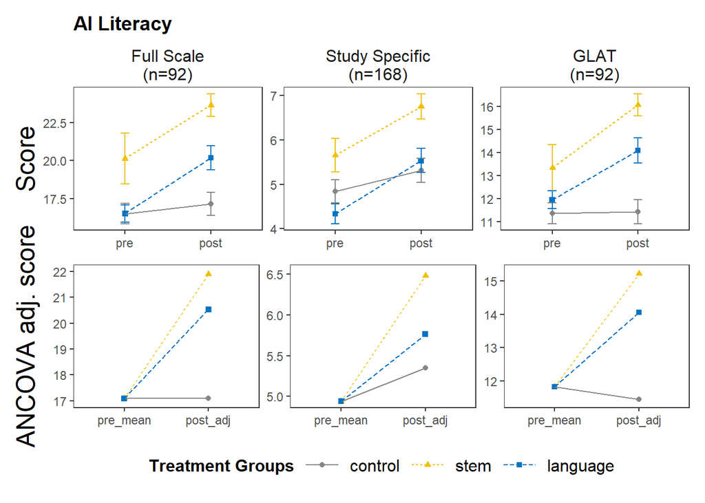

Figure 1: Descriptive Statistics of Students’ AI Literacy Scores Over Time by Treatment Group.

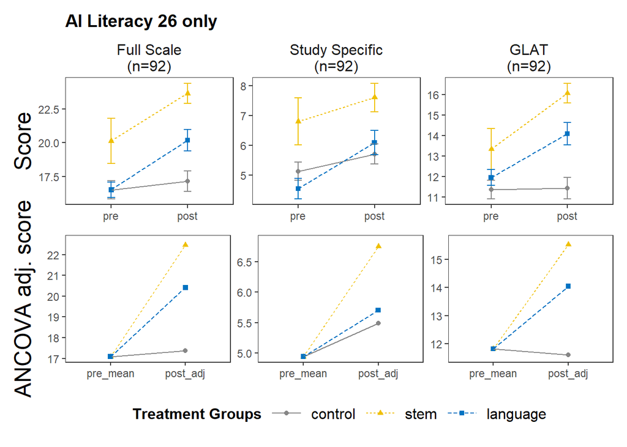

Figure 2: Descriptive Statistics of Students’ AI Literacy Scores Over Time by Treatment Group.

```r
ft_ailit_ancova <- modelsummary_models(
  ancovas[names(ancovas) %in% outcomes_ailit],
  outcomes = outcomes_ailit,
  output = modelsummary_output
) # %>%   kableExtra::scroll_box(width = "100%")

if (is_word) {
  ft_ailit_ancova <- adjust_table_for_word(ft_ailit_ancova, width = .75)
}
ft_ailit_ancova
```

Table 2: Summary of Multiple Regression Models for AI Literacy.

|  | AILIT26 β | AILIT26 SE | AILIT26 t | AILIT26 p | AILITwolke β | AILITwolke SE | AILITwolke t | AILITwolke p | AILITglat β | AILITglat SE | AILITglat t | AILITglat p |
| --- | --- | --- | --- | --- | --- | --- | --- | --- | --- | --- | --- | --- |
| (Intercept) | -1.57*** | 0.43 | -3.64 | <0.001 | -1.41*** | 0.25 | -5.58 | <0.001 | -1.32** | 0.40 | -3.28 | 0.001 |
| intervention-c+STEM_language | 0.74*** | 0.18 | 4.11 | <0.001 | 0.33* | 0.14 | 2.38 | 0.018 | 0.83*** | 0.19 | 4.43 | <0.001 |
| intervention-STEM+language | -0.36 | 0.23 | -1.56 | 0.122 | -0.45* | 0.19 | -2.34 | 0.021 | -0.44+ | 0.24 | -1.81 | 0.074 |
| pretest | 0.07* | 0.03 | 2.63 | 0.010 | 0.17*** | 0.03 | 5.20 | <0.001 | 0.10* | 0.04 | 2.49 | 0.015 |
| gender-f+m | -0.07 | 0.19 | -0.36 | 0.716 | -0.06 | 0.16 | -0.37 | 0.714 | -0.18 | 0.20 | -0.90 | 0.372 |
| semester | 0.06 | 0.05 | 1.10 | 0.276 | 0.07* | 0.03 | 2.50 | 0.014 | 0.04 | 0.05 | 0.81 | 0.422 |
| Num.Obs. | 92 |  |  |  | 168 |  |  |  | 92 |  |  |  |
| R2 | 0.360 |  |  |  | 0.272 |  |  |  | 0.345 |  |  |  |
| R2 Adj. | 0.322 |  |  |  | 0.250 |  |  |  | 0.307 |  |  |  |
| AIC | 233.1 |  |  |  | 436.4 |  |  |  | 235.1 |  |  |  |
| BIC | 250.7 |  |  |  | 458.3 |  |  |  | 252.8 |  |  |  |
| RMSE | 0.80 |  |  |  | 0.85 |  |  |  | 0.80 |  |  |  |

```r
if (!is_word) {
  cat("### Pairwise Contrasts Between Groups")
}
```

### 4.1.1 Pairwise Contrasts Between Groups

```r
# pairwise between contrasts (no multiplicity adjustment)
ailit_ancova_between_contrasts <- lapply(ancovas[1:3], function(m) {
  emmeans(m, ~intervention) %>%
    contrast(interaction = "pairwise", adjust = "none")
})
if (!is_word) {
  print(ailit_ancova_between_contrasts)
}
```

```
$AILIT26
 intervention_pairwise estimate    SE df t.ratio p.value
 control - stem          -0.924 0.211 86  -4.382 <0.0001
 control - language      -0.563 0.219 86  -2.576  0.0117
 stem - language          0.361 0.231 86   1.563  0.1217

Results are averaged over the levels of: gender

$AILITwolke
 intervention_pairwise estimate    SE  df t.ratio p.value
 control - stem          -0.558 0.163 162  -3.412  0.0008
 control - language      -0.110 0.176 162  -0.624  0.5332
 stem - language          0.448 0.192 162   2.338  0.0206

Results are averaged over the levels of: gender

$AILITglat
 intervention_pairwise estimate    SE df t.ratio p.value
 control - stem          -1.053 0.224 86  -4.703 <0.0001
 control - language      -0.613 0.224 86  -2.732  0.0076
 stem - language          0.440 0.243 86   1.809  0.0739

Results are averaged over the levels of: gender
```

```r
ailit_ancova_between_contrasts
```

```
$AILIT26
 intervention_pairwise estimate    SE df t.ratio p.value
 control - stem          -0.924 0.211 86  -4.382 <0.0001
 control - language      -0.563 0.219 86  -2.576  0.0117
 stem - language          0.361 0.231 86   1.563  0.1217

Results are averaged over the levels of: gender

$AILITwolke
 intervention_pairwise estimate    SE  df t.ratio p.value
 control - stem          -0.558 0.163 162  -3.412  0.0008
 control - language      -0.110 0.176 162  -0.624  0.5332
 stem - language          0.448 0.192 162   2.338  0.0206

Results are averaged over the levels of: gender

$AILITglat
 intervention_pairwise estimate    SE df t.ratio p.value
 control - stem          -1.053 0.224 86  -4.703 <0.0001
 control - language      -0.613 0.224 86  -2.732  0.0076
 stem - language          0.440 0.243 86   1.809  0.0739

Results are averaged over the levels of: gender
```

### 4.1.2 AI Literacy – Full Scale

For the full AI literacy scale, students in the intervention groups showed significantly greater improvement than students in the control group, $\beta$ = 0.74, *SE* = 0.18, *t*(86) = 4.11, *p* < .001, indicating a large positive effect in favor of the intervention groups. The two intervention groups did not differ significantly from each other, $\beta$ = -0.36, *SE* = 0.23, *t*(86) = -1.56, *p* = .122.

### 4.1.3 AI Literacy – Study Specific Subset

For the study-specific subset of the AI literacy items, we found a significant small-to-medium-sized effect of treatment condition on students’ gains in AI literacy, $\beta$ = 0.33, *SE* = 0.14, *t*(162) = 2.38, *p* = .018, with students in the intervention groups showing significantly stronger gains than students in the control group. In addition, the two intervention groups differed significantly, $\beta$ = -0.45, *SE* = 0.19, *t*(162) = -2.34, *p* = .021, with a medium-sized effect in favor of pre-service STEM teachers compared to pre-service language teachers.

### 4.1.4 AI Literacy – GLAT Subset

For the GLAT subset of the AI literacy items, we found a significant large effect of treatment condition on students’ gains in AI literacy, $\beta$ = 0.83, *SE* = 0.19, *t*(86) = 4.43, *p* < .001, indicating stronger gains in the intervention groups than in the control group. The two intervention groups did not differ significantly, $\beta$ = -0.44, *SE* = 0.24, *t*(86) = -1.81, *p* = .074.

As can be seen in Figure 1, students in both intervention groups showed descriptively stronger increases in AI literacy than students in the control group. Pairwise post-hoc contrasts showed that students in the STEM course had significantly higher adjusted posttest scores than students in the control group on all three AI literacy outcomes: the full scale, $\beta$ = -0.92, *SE* = 0.21, *t*(86) = -4.38, *p* < .001, the study-specific subset, $\beta$ = -0.56, *SE* = 0.16, *t*(162) = -3.41, *p* < .001, and the GLAT subset, $\beta$ = -1.05, *SE* = 0.22, *t*(86) = -4.70, *p* < .001. Students in the language course also had significantly higher adjusted posttest scores than students in the control group on the full scale, $\beta$ = -0.56, *SE* = 0.22, *t*(86) = -2.58, *p* = .012, and the GLAT subset, $\beta$ = -0.61, *SE* = 0.22, *t*(86) = -2.73, *p* = .008, but not on the study-specific subset, $\beta$ = -0.11, *SE* = 0.18, *t*(162) = -0.62, *p* = .533. Finally, students in the STEM course had significantly higher adjusted posttest scores than students in the language course on the study-specific subset, $\beta$ = 0.45, *SE* = 0.19, *t*(162) = 2.34, *p* = .021, while the corresponding difference on the GLAT subset was marginally significant, $\beta$ = 0.44, *SE* = 0.24, *t*(86) = 1.81, *p* = .074.

## 4.2 Intelligent TPACK and AI Ethics

The descriptive results of students’ ratings of perceived knowledge in Intelligent TPACK and AI ethics as well as the ANCOVA-adjusted predicted posttest ratings are shown in Figure 3, and Table 3 lists the results of the ANCOVA. As can be seen in Figure 3, all pre-service teachers reported their intelligent TPACK knowledge to be around the middle of the scale at the pretest, while the intervention groups reported, on average, values *significantly* higher than the middle value of the scale at the posttest.

For all subscales related to Intelligent TPACK, namely Intelligent TK, Intelligent TPK, Intelligent TCK, Intelligent TPACK, and AI ethics, we found a significant effect of treatment condition on students’ self-reported posttest ratings. Students in both intervention groups reported significantly higher posttest ratings than students in the control group on the Intelligent TPACK-related subscales, whereas the two intervention groups did not differ significantly from each other, see Table 3 for an overview.

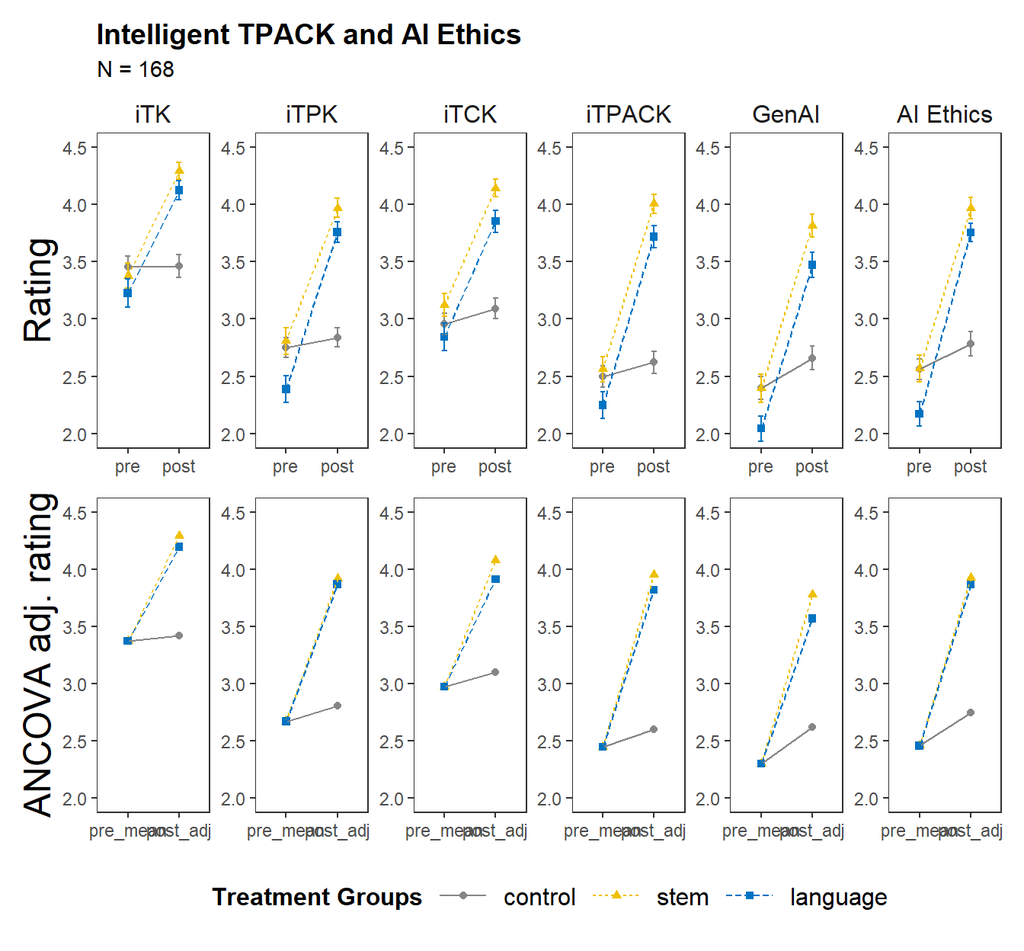

Figure 3: Descriptive Statistics of Students’ Intelligent TPACK and AI Ethics Ratings Over Time by Treatment Group.

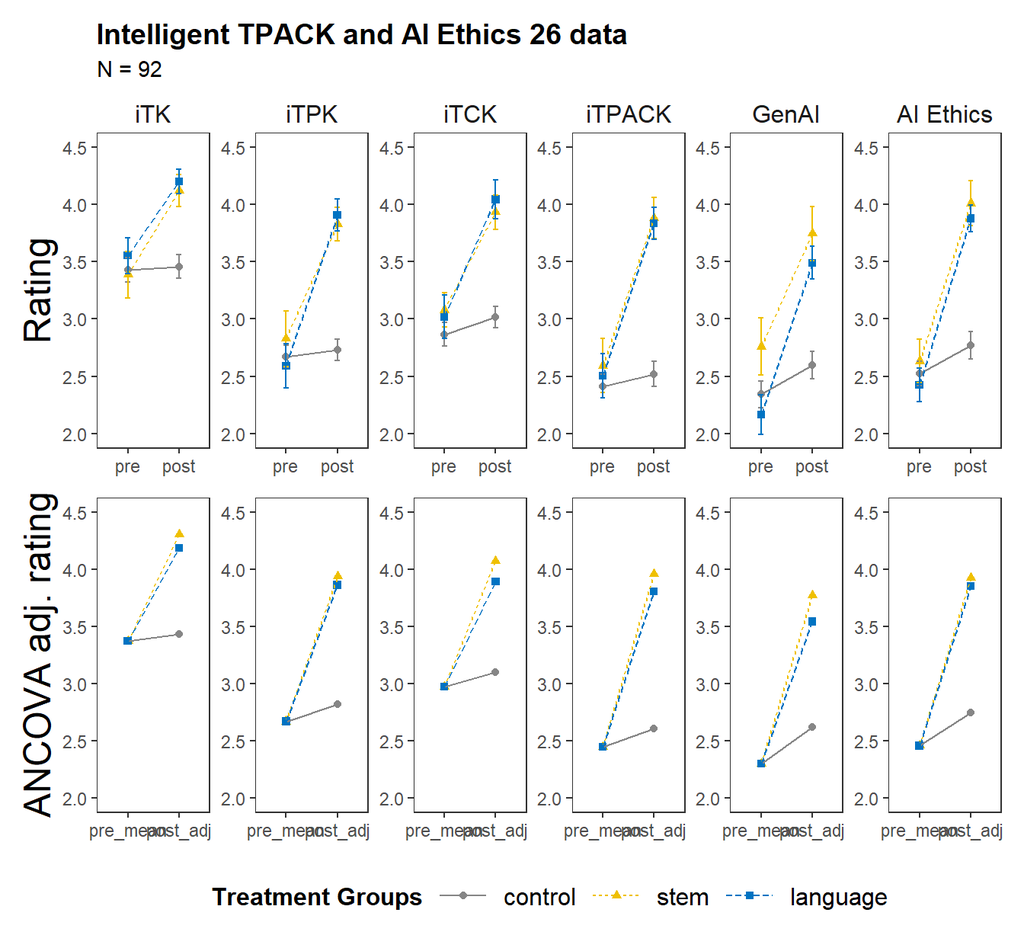

Figure 4: Descriptive Statistics of Students’ Intelligent TPACK and AI Ethics Ratings Over Time by Treatment Group.

```r
ft_ancova <- modelsummary_models(
  ancovas[grepl("^(T|Ethics)", names(ancovas))],
  outcomes = outcomes %>% grep("^(T|Ethics)", ., value = TRUE),
  output = modelsummary_output,
) # %>%   kableExtra::scroll_box(width = "100%")

if (is_word) {
  ft_ancova <- adjust_table_for_word(ft_ancova, width = 1)
}
ft_ancova
```

Table 3: Summary of Multiple Regression Models for Intelligent TPACK Subscales and AI Ethics

|  | TK β | TK SE | TK t | TK p | TPK β | TPK SE | TPK t | TPK p | TCK β | TCK SE | TCK t | TCK p | TPACKce β | TPACKce SE | TPACKce t | TPACKce p | TPACKgenai β | TPACKgenai SE | TPACKgenai t | TPACKgenai p | Ethics β | Ethics SE | Ethics t | Ethics p |
| --- | --- | --- | --- | --- | --- | --- | --- | --- | --- | --- | --- | --- | --- | --- | --- | --- | --- | --- | --- | --- | --- | --- | --- | --- |
| (Intercept) | -2.15*** | 0.34 | -6.31 | <0.001 | -1.23*** | 0.32 | -3.89 | <0.001 | -1.47*** | 0.32 | -4.52 | <0.001 | -1.20*** | 0.29 | -4.10 | <0.001 | -0.77** | 0.28 | -2.72 | 0.007 | -0.88** | 0.31 | -2.79 | 0.006 |
| intervention-c+STEM_language | 1.06*** | 0.12 | 9.13 | <0.001 | 1.30*** | 0.11 | 11.77 | <0.001 | 1.09*** | 0.11 | 9.88 | <0.001 | 1.35*** | 0.10 | 13.54 | <0.001 | 1.10*** | 0.12 | 9.05 | <0.001 | 1.23*** | 0.12 | 10.23 | <0.001 |
| intervention-STEM+language | -0.11 | 0.14 | -0.78 | 0.435 | -0.07 | 0.16 | -0.45 | 0.653 | -0.11 | 0.17 | -0.66 | 0.507 | -0.10 | 0.14 | -0.75 | 0.455 | -0.11 | 0.18 | -0.63 | 0.532 | -0.01 | 0.16 | -0.09 | 0.928 |
| pretest | 0.64*** | 0.07 | 8.74 | <0.001 | 0.47*** | 0.08 | 5.97 | <0.001 | 0.54*** | 0.08 | 6.94 | <0.001 | 0.53*** | 0.07 | 7.90 | <0.001 | 0.40*** | 0.08 | 5.23 | <0.001 | 0.41*** | 0.09 | 4.69 | <0.001 |
| gender-f+m | 0.07 | 0.14 | 0.52 | 0.606 | 0.01 | 0.13 | 0.09 | 0.931 | 0.23* | 0.11 | 2.07 | 0.040 | 0.11 | 0.12 | 0.91 | 0.364 | 0.28* | 0.14 | 2.03 | 0.043 | 0.13 | 0.14 | 0.90 | 0.367 |
| semester | 0.01 | 0.02 | 0.63 | 0.532 | 0.01 | 0.02 | 0.60 | 0.551 | 0.00 | 0.02 | 0.14 | 0.885 | 0.01 | 0.03 | 0.34 | 0.737 | 0.00 | 0.03 | 0.10 | 0.919 | 0.00 | 0.03 | 0.14 | 0.888 |
| Num.Obs. | 168 |  |  |  | 168 |  |  |  | 168 |  |  |  | 168 |  |  |  | 168 |  |  |  | 168 |  |  |  |
| R2 | 0.523 |  |  |  | 0.522 |  |  |  | 0.515 |  |  |  | 0.619 |  |  |  | 0.428 |  |  |  | 0.446 |  |  |  |
| R2 Adj. | 0.508 |  |  |  | 0.507 |  |  |  | 0.500 |  |  |  | 0.607 |  |  |  | 0.411 |  |  |  | 0.429 |  |  |  |
| AIC | 365.4 |  |  |  | 365.8 |  |  |  | 368.4 |  |  |  | 327.5 |  |  |  | 395.9 |  |  |  | 390.5 |  |  |  |
| BIC | 387.3 |  |  |  | 387.7 |  |  |  | 390.2 |  |  |  | 349.4 |  |  |  | 417.7 |  |  |  | 412.4 |  |  |  |
| RMSE | 0.69 |  |  |  | 0.69 |  |  |  | 0.69 |  |  |  | 0.62 |  |  |  | 0.75 |  |  |  | 0.74 |  |  |  |

### 4.2.1 Intelligent TK

For Intelligent TK, students in the intervention groups reported significantly greater improvement than students in the control group, $\beta$ = 1.06, *SE* = 0.12, *t*(162) = 9.13, *p* < .001, indicating a large positive effect in favor of the intervention groups. The two intervention groups did not differ significantly from each other, $\beta$ = -0.11, *SE* = 0.14, *t*(162) = -0.78, *p* = .435.

### 4.2.2 Intelligent TPK

For Intelligent TPK, students in the intervention groups reported significantly greater improvement than students in the control group, $\beta$ = 1.30, *SE* = 0.11, *t*(162) = 11.77, *p* < .001, indicating a large positive effect in favor of the intervention groups. The two intervention groups did not differ significantly from each other, $\beta$ = -0.07, *SE* = 0.16, *t*(162) = -0.45, *p* = .653.

### 4.2.3 Intelligent TCK

For Intelligent TCK, students in the intervention groups reported significantly greater improvement than students in the control group, $\beta$ = 1.09, *SE* = 0.11, *t*(162) = 9.88, *p* < .001, indicating a large positive effect in favor of the intervention groups. The two intervention groups did not differ significantly from each other, $\beta$ = -0.11, *SE* = 0.17, *t*(162) = -0.66, *p* = .507.

### 4.2.4 Intelligent TPACK Core

For the Intelligent TPACK core subscale, students in the intervention groups reported significantly greater improvement than students in the control group, $\beta$ = 1.35, *SE* = 0.10, *t*(162) = 13.54, *p* < .001, indicating a large positive effect in favor of the intervention groups. The two intervention groups did not differ significantly from each other, $\beta$ = -0.10, *SE* = 0.14, *t*(162) = -0.75, *p* = .455.

### 4.2.5 Intelligent TPACK (GenAI)

For Intelligent TPACK related to GenAI, students in the intervention groups reported significantly greater improvement than students in the control group, $\beta$ = 1.10, *SE* = 0.12, *t*(162) = 9.05, *p* < .001, indicating a large positive effect in favor of the intervention groups. The two intervention groups did not differ significantly from each other, $\beta$ = -0.11, *SE* = 0.18, *t*(162) = -0.63, *p* = .532.

### 4.2.6 AI Ethics

For AI ethics, students in the intervention groups reported significantly greater improvement than students in the control group, $\beta$ = 1.23, *SE* = 0.12, *t*(162) = 10.23, *p* < .001, indicating a large positive effect in favor of the intervention groups. The two intervention groups did not differ significantly from each other, $\beta$ = -0.01, *SE* = 0.16, *t*(162) = -0.09, *p* = .928.

## 4.3 Critical Evaluation of AI (CEA)

**Note**

Note für uns: ggf. reduzieren wir CEA auf eine Skala mit 9 Items. Im Piloten haben wir 15 items getestet und EFA hat gezeigt, dass Reduktion auf 2 Skalen möglich wäre. Das haben wir gemacht, und die funktionieren auch, aber ein Item lädt z.B. ziemlich stark auf die andere Skala. Entweder bekommt man das gut begründet, aber den richtigen Mehrwert sehe ich nicht, 2 Skalen aufzustellen. So oder so, es haben alle Skalen gut funktioniert und zeigen den Mehrwert vom Seminar. Ggf. einfach auf eine Full Scale runterbrechen, sagen dass man den fragebogen soweit möglich evaluiert hat, items reduziert hat und das reicht dann.

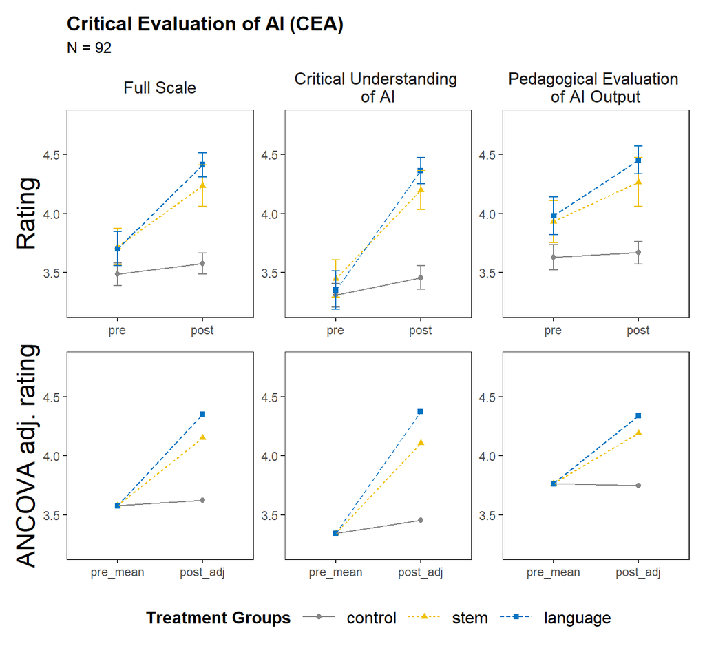

Figure 5: Descriptive Statistics of Students’ Critical Evaluation of AI Over Time by Treatment Group.

```r
ft_cea_ancova <- modelsummary_models(
  ancovas[grepl("^(CEA)", names(ancovas))],
  outcomes = c("CEA", "CEA_understanding", "CEA_ped"),
  output = modelsummary_output,
) # %>%   kableExtra::scroll_box(width = "100%")

if (is_word) {
  ft_cea_ancova <- adjust_table_for_word(ft_cea_ancova, width = .75)
}
ft_cea_ancova
```

Table 4: Summary of Multiple Regression Models for CEA subscale.

|  | CEA β | CEA SE | CEA t | CEA p | CEA_understanding β | CEA_understanding SE | CEA_understanding t | CEA_understanding p | CEA_ped β | CEA_ped SE | CEA_ped t | CEA_ped p |
| --- | --- | --- | --- | --- | --- | --- | --- | --- | --- | --- | --- | --- |
| (Intercept) | -2.50*** | 0.56 | -4.46 | <0.001 | -2.03*** | 0.49 | -4.12 | <0.001 | -2.34*** | 0.63 | -3.72 | <0.001 |
| intervention-c+STEM_language | 0.86*** | 0.18 | 4.93 | <0.001 | 0.99*** | 0.17 | 5.74 | <0.001 | 0.67*** | 0.19 | 3.58 | <0.001 |
| intervention-STEM+language | 0.29 | 0.29 | 0.99 | 0.324 | 0.31 | 0.29 | 1.07 | 0.287 | 0.24 | 0.29 | 0.83 | 0.409 |
| pretest | 0.75*** | 0.12 | 6.15 | <0.001 | 0.61*** | 0.11 | 5.53 | <0.001 | 0.70*** | 0.13 | 5.28 | <0.001 |
| gender-f+m | 0.06 | 0.22 | 0.25 | 0.800 | 0.04 | 0.20 | 0.19 | 0.850 | 0.08 | 0.24 | 0.32 | 0.750 |
| semester | 0.01 | 0.04 | 0.16 | 0.871 | 0.03 | 0.03 | 0.85 | 0.396 | -0.01 | 0.04 | -0.21 | 0.835 |
| Num.Obs. | 92 |  |  |  | 92 |  |  |  | 92 |  |  |  |
| R2 | 0.540 |  |  |  | 0.486 |  |  |  | 0.486 |  |  |  |
| R2 Adj. | 0.514 |  |  |  | 0.456 |  |  |  | 0.456 |  |  |  |
| AIC | 202.6 |  |  |  | 212.8 |  |  |  | 212.8 |  |  |  |
| BIC | 220.2 |  |  |  | 230.4 |  |  |  | 230.4 |  |  |  |
| RMSE | 0.67 |  |  |  | 0.71 |  |  |  | 0.71 |  |  |  |

### 4.3.1 CEA

For the overall CEA scale, students in the intervention groups reported significantly greater improvement than students in the control group, $\beta$ = 0.86, *SE* = 0.18, *t*(86) = 4.93, *p* < .001, indicating a large positive effect in favor of the intervention groups. The two intervention groups did not differ significantly from each other, $\beta$ = 0.29, *SE* = 0.29, *t*(86) = 0.99, *p* = .324.

### 4.3.2 CEA Understanding

For CEA understanding, students in the intervention groups reported significantly greater improvement than students in the control group, $\beta$ = 0.99, *SE* = 0.17, *t*(86) = 5.74, *p* < .001, indicating a large positive effect in favor of the intervention groups. The two intervention groups did not differ significantly from each other, $\beta$ = 0.31, *SE* = 0.29, *t*(86) = 1.07, *p* = .287.

### 4.3.3 CEA Pedagogical Use

For CEA pedagogical use, students in the intervention groups reported significantly greater improvement than students in the control group, $\beta$ = 0.67, *SE* = 0.19, *t*(86) = 3.58, *p* < .001, indicating a medium-to-large positive effect in favor of the intervention groups. The two intervention groups did not differ significantly from each other, $\beta$ = 0.24, *SE* = 0.29, *t*(86) = 0.83, *p* = .409.

## 4.4 CEA Validity

The newly developed CEA scale showed good internal consistency at pretest, Cronbach’s α = .86. Internal consistency was acceptable for CEA understanding, α = .66, and good for CEA pedagogical use, α = .83. The data were suitable for factor analysis, KMO = .87; Bartlett’s test: χ²(36) = 518.49, *p* < .001. Parallel analysis suggested a two-factor solution. The two-factor EFA showed acceptable fit, χ²(19) = 29.23, *p* = .062, CFI = .982, RMSEA = .079, and explained 63.9% of the variance, broadly supporting a two-dimensional structure of the scale.

```r
# cronbach alpha
alphas <- imap(
  list_items_cea,
  ~ psych::alpha(
    dplyr::select(data_merged_pre, dplyr::all_of(.x)),
    warnings = FALSE
  )
)
(alphas$CEA)$total
```

```
 raw_alpha std.alpha   G6(smc) average_r      S/N        ase     mean        sd
 0.8555533 0.8599656 0.8912677 0.4055916 6.141104 0.01704271 3.576087 0.6904448
 median_r
 0.397035
```

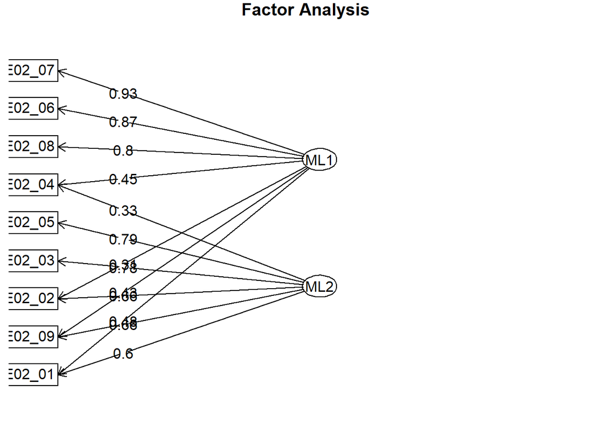

```r
# 0.86 alpha, kein item lohnt sich rauszunehmen

data_merged_post <- data_merged %>% filter(time == "post" & CEA != "NaN")
# EFA
ncomp <- 2
# EFA
df_cea_items <- data_merged_post %>%
  select(all_of(list_items_cea$CEA)) %>%
  na.omit()
cea_scale <- list_items_cea %>% unlist(use.names = F)

efa_promax <- df_cea_items %>%
  select(any_of(cea_scale)) %>%
  psych::fa(nfactors = ncomp, rotate = "varimax", fm = "ml", missing = T)

# print(efa_promax, digits = 2, cut = .3, sort = F)
fa.diagram(efa_promax, digits = 2, cut = .30, simple = FALSE)
```

```r
## Computing EFA using the lavaan package
cea_efa <- lavaan::efa(
  df_cea_items %>%
    select(any_of(cea_scale)),
  nfactors = ncomp,
  rotation = "varimax",
  ordered = F,
  std.lv = TRUE,
  missing = "fiml"
)

summary(cea_efa, nd = 3L, cutoff = 0.3, dot.cutoff = 0.05)
```

```
  Estimator                                         ML
  Rotation method                   VARIMAX ORTHOGONAL
  Rotation algorithm (rstarts)                GPA (30)
  Standardized metric                             TRUE
  Row weights                                   Kaiser

  Number of observations                            92
  Number of missing patterns                         1

Fit measures:
                    aic      bic    sabic  chisq df pvalue   cfi rmsea
  nfactors = 2 1866.465 1954.728 1844.248 29.229 19  0.062 0.982 0.079

Eigenvalues correlation matrix:

    ev1     ev2     ev3     ev4     ev5     ev6     ev7     ev8     ev9
  4.986   1.394   0.746   0.554   0.381   0.330   0.268   0.217   0.124

Standardized loadings: (* = significant at 1% level)

            f1      f2       unique.var   communalities
RE02_01  0.604*  0.479*           0.406           0.594
RE02_02  0.656*  0.306*           0.476           0.524
RE02_03  0.783*      .            0.383           0.617
RE02_04  0.328*  0.445*           0.694           0.306
RE02_05  0.787*      .*           0.319           0.681
RE02_06      .*  0.873*           0.193           0.807
RE02_07      .*  0.925*           0.080           0.920
RE02_08      .*  0.797*           0.310           0.690
RE02_09  0.656*  0.425*           0.389           0.611

                              f2    f1 total
Sum of sq (ortho) loadings 3.018 2.732 5.750
Proportion of total        0.525 0.475 1.000
Proportion var             0.335 0.304 0.639
Cumulative var             0.335 0.639 0.639
```

## 4.5 Two Groups (Control vs. Intervention)

```r
modelsummary_models(
  ancovas_two_groups,
  outcomes = outcomes,
  output = modelsummary_output
)
```

Table 5: Summary of Multiple Linear Regression Models for Two Treatment Groups.

|  | AILIT26 β | AILIT26 SE | AILIT26 t | AILIT26 p | AILITwolke β | AILITwolke SE | AILITwolke t | AILITwolke p | AILITglat β | AILITglat SE | AILITglat t | AILITglat p | TK β | TK SE | TK t | TK p | TPK β | TPK SE | TPK t | TPK p | TCK β | TCK SE | TCK t | TCK p | TPACKce β | TPACKce SE | TPACKce t | TPACKce p | TPACKgenai β | … |
| --- | --- | --- | --- | --- | --- | --- | --- | --- | --- | --- | --- | --- | --- | --- | --- | --- | --- | --- | --- | --- | --- | --- | --- | --- | --- | --- | --- | --- | --- | --- |
| (Intercept) | -2.12*** | 0.41 | -5.12 | <0.001 | -1.56*** | 0.25 | -6.31 | <0.001 | -1.91*** | 0.39 | -4.89 | <0.001 | -2.82*** | 0.35 | -8.05 | <0.001 | -2.09*** | 0.33 | -6.31 | <0.001 | -2.17*** | 0.33 | -6.65 | <0.001 | -2.08*** | 0.30 | -6.99 | <0.001 | -1.48*** | … |
| treatmentintervention | 0.71*** | 0.18 | 3.84 | <0.001 | 0.34* | 0.14 | 2.42 | 0.017 | 0.80*** | 0.19 | 4.13 | <0.001 | 1.06*** | 0.12 | 9.17 | <0.001 | 1.31*** | 0.11 | 11.83 | <0.001 | 1.09*** | 0.11 | 9.98 | <0.001 | 1.35*** | 0.10 | 13.57 | <0.001 | 1.10*** | … |
| pretest | 0.08** | 0.03 | 2.82 | 0.006 | 0.19*** | 0.03 | 5.89 | <0.001 | 0.10* | 0.04 | 2.60 | 0.011 | 0.64*** | 0.07 | 8.87 | <0.001 | 0.47*** | 0.08 | 6.12 | <0.001 | 0.54*** | 0.08 | 7.06 | <0.001 | 0.53*** | 0.07 | 7.96 | <0.001 | 0.40*** | … |
| gender-f+m | 0.01 | 0.18 | 0.07 | 0.941 | 0.06 | 0.16 | 0.39 | 0.696 | -0.08 | 0.18 | -0.42 | 0.675 | 0.10 | 0.13 | 0.81 | 0.418 | 0.03 | 0.12 | 0.25 | 0.804 | 0.26* | 0.11 | 2.35 | 0.020 | 0.14 | 0.11 | 1.20 | 0.233 | 0.31* | … |
| semester | 0.06 | 0.05 | 1.13 | 0.263 | 0.05* | 0.03 | 2.06 | 0.041 | 0.04 | 0.05 | 0.85 | 0.396 | 0.01 | 0.02 | 0.51 | 0.613 | 0.01 | 0.02 | 0.53 | 0.595 | -0.00 | 0.02 | -0.01 | 0.992 | 0.01 | 0.02 | 0.23 | 0.818 | -0.00 | … |
| Num.Obs. | 92 |  |  |  | 168 |  |  |  | 92 |  |  |  | 168 |  |  |  | 168 |  |  |  | 168 |  |  |  | 168 |  |  |  | 168 | … |
| R2 | 0.349 |  |  |  | 0.249 |  |  |  | 0.329 |  |  |  | 0.521 |  |  |  | 0.521 |  |  |  | 0.513 |  |  |  | 0.618 |  |  |  | 0.427 | … |
| R2 Adj. | 0.319 |  |  |  | 0.231 |  |  |  | 0.298 |  |  |  | 0.510 |  |  |  | 0.510 |  |  |  | 0.501 |  |  |  | 0.609 |  |  |  | 0.413 | … |
| AIC | 232.6 |  |  |  | 439.5 |  |  |  | 235.4 |  |  |  | 363.9 |  |  |  | 364.0 |  |  |  | 366.9 |  |  |  | 326.1 |  |  |  | 394.3 | … |
| BIC | 247.7 |  |  |  | 458.3 |  |  |  | 250.5 |  |  |  | 382.7 |  |  |  | 382.8 |  |  |  | 385.6 |  |  |  | 344.8 |  |  |  | 413.0 | … |
| RMSE | 0.80 |  |  |  | 0.86 |  |  |  | 0.81 |  |  |  | 0.69 |  |  |  | 0.69 |  |  |  | 0.70 |  |  |  | 0.62 |  |  |  | 0.75 | … |

```r
# save environment
save.image("data/env-analysis.Rdata")
```

## References

Arel-Bundock, V. (2022). modelsummary: Data and model summaries in R. *Journal of Statistical Software*, *103*(1), 1–23. https://doi.org/10.18637/jss.v103.i01

Authors. (in prep.). *Development and Validation of a German Version of the Intelligent-TPACK*.

Behling, O., & Law, K. (2025). *Translating Questionnaires and Other Research Instruments*. SAGE Publications, Inc. https://doi.org/10.4135/9781412986373

Blair, G., Cooper, J., Coppock, A., Humphreys, M., & Sonnet, L. (2025). *Estimatr: Fast estimators for design-based inference*. https://declaredesign.org/r/estimatr/

Celik, I. (2023). Towards Intelligent-TPACK: An empirical study on teachers’ professional knowledge to ethically integrate artificial intelligence (AI)-based tools into education. *Computers in Human Behavior*, *138*, 107468. https://doi.org/10.1016/j.chb.2022.107468

Clearinghouse, W. W. (2022). What works clearinghouse procedures and standards handbook, version 5.0. US department of education, institute of education sciences. *National Center for Education Evaluation and Regional Assistance (NCEE)*. https://ies.ed.gov/ncee/wwc/Handbooks

Heinzen, E., Sinnwell, J., Atkinson, E., Gunderson, T., & Dougherty, G. (2021). *Arsenal: An arsenal of ’r’ functions for large-scale statistical summaries*. https://github.com/mayoverse/arsenal

Huntington-Klein, N. (2023). *Vtable: Variable table for variable documentation*. https://nickch-k.github.io/vtable/

Lenth, R. V. (2025). *Emmeans: Estimated marginal means, aka least-squares means*. https://rvlenth.github.io/emmeans/

Levenshtein, V. I. (1966). Binary Codes Capable of Correcting Deletions, Insertions and Reversals. *Soviet Physics Doklady*, *10*(8). https://nymity.ch/sybilhunting/pdf/Levenshtein1966a.pdf

Long, J. A. (2022). *Jtools: Analysis and presentation of social scientific data*. https://cran.r-project.org/package=jtools

Long, J. S., & Ervin, L. H. (2000). Using heteroscedasticity consistent standard errors in the linear regression model. *The American Statistician*, *54*(3), 217–224. https://doi.org/10.1080/00031305.2000.10474549

Marsh, H. W., Lüdtke, O., Robitzsch, A., Trautwein, U., Asparouhov, T., Muthén, B., & Nagengast, B. (2009). Doubly-Latent Models of School Contextual Effects: Integrating Multilevel and Structural Equation Approaches to Control Measurement and Sampling Error. *Multivariate Behavioral Research*, *44*(6), 764–802. https://doi.org/10.1080/00273170903333665

R Core Team. (2024). *R: A language and environment for statistical computing*. R Foundation for Statistical Computing. https://www.R-project.org/

Warnes, G. R., Bolker, B., Lumley, T., Magnusson, A., Venables, B., Ryodan, G., & Moeller, S. (2023). *Gtools: Various r programming tools*. https://github.com/r-gregmisc/gtools

Wickham, H. (2016). *ggplot2: Elegant graphics for data analysis*. Springer-Verlag New York. https://ggplot2.tidyverse.org

Wickham, H., Vaughan, D., & Girlich, M. (2024). *Tidyr: Tidy messy data*. https://tidyr.tidyverse.org

Xiao, N. (2024). *Ggsci: Scientific journal and sci-fi themed color palettes for ’ggplot2’*. https://nanx.me/ggsci/

Zhu, H. (2024). *kableExtra: Construct complex table with ’kable’ and pipe syntax*. http://haozhu233.github.io/kableExtra/